# Risk Factor Analysis

## Outcome Variable

**Outcome Variable:** s03rec24

## Predictor Variables

**Intervention Variable:** enstunt

**Adjustment Set:**

- arm
- sex
- W_mage
- meducyrs
- hhwealth_quart
- brthmon
- W_parity
- delta_W_mage
- delta_meducyrs
- delta_hhwealth_quart
- delta_brthmon
- delta_W_parity

## Stratifying Variables

The analysis was stratified on these variable(s):

- studyid
- country

## Data Summary

| studyid | country | enstunt | s03rec24 | n_cell | n |
| --- | --- | --- | --- | --- | --- |
| ki0047075b-MAL-ED | BANGLADESH | 0 | 0 | 213 | 247 |
| ki0047075b-MAL-ED | BANGLADESH | 0 | 1 | 1 | 247 |
| ki0047075b-MAL-ED | BANGLADESH | 1 | 0 | 26 | 247 |
| ki0047075b-MAL-ED | BANGLADESH | 1 | 1 | 7 | 247 |
| ki0047075b-MAL-ED | BRAZIL | 0 | 0 | 204 | 223 |
| ki0047075b-MAL-ED | BRAZIL | 0 | 1 | 3 | 223 |
| ki0047075b-MAL-ED | BRAZIL | 1 | 0 | 1 | 223 |
| ki0047075b-MAL-ED | BRAZIL | 1 | 1 | 15 | 223 |
| ki0047075b-MAL-ED | INDIA | 0 | 0 | 208 | 246 |
| ki0047075b-MAL-ED | INDIA | 0 | 1 | 1 | 246 |
| ki0047075b-MAL-ED | INDIA | 1 | 0 | 25 | 246 |
| ki0047075b-MAL-ED | INDIA | 1 | 1 | 12 | 246 |
| ki0047075b-MAL-ED | NEPAL | 0 | 0 | 211 | 238 |
| ki0047075b-MAL-ED | NEPAL | 0 | 1 | 1 | 238 |
| ki0047075b-MAL-ED | NEPAL | 1 | 0 | 16 | 238 |
| ki0047075b-MAL-ED | NEPAL | 1 | 1 | 10 | 238 |
| ki0047075b-MAL-ED | PERU | 0 | 0 | 245 | 284 |
| ki0047075b-MAL-ED | PERU | 0 | 1 | 11 | 284 |
| ki0047075b-MAL-ED | PERU | 1 | 0 | 20 | 284 |
| ki0047075b-MAL-ED | PERU | 1 | 1 | 8 | 284 |
| ki0047075b-MAL-ED | SOUTH AFRICA | 0 | 0 | 272 | 302 |
| ki0047075b-MAL-ED | SOUTH AFRICA | 0 | 1 | 7 | 302 |
| ki0047075b-MAL-ED | SOUTH AFRICA | 1 | 0 | 11 | 302 |
| ki0047075b-MAL-ED | SOUTH AFRICA | 1 | 1 | 12 | 302 |
| ki0047075b-MAL-ED | TANZANIA, UNITED REPUBLIC OF | 0 | 0 | 218 | 253 |
| ki0047075b-MAL-ED | TANZANIA, UNITED REPUBLIC OF | 0 | 1 | 0 | 253 |
| ki0047075b-MAL-ED | TANZANIA, UNITED REPUBLIC OF | 1 | 0 | 34 | 253 |
| ki0047075b-MAL-ED | TANZANIA, UNITED REPUBLIC OF | 1 | 1 | 1 | 253 |
| ki1000108-CMC-V-BCS-2002 | INDIA | 0 | 0 | 289 | 370 |
| ki1000108-CMC-V-BCS-2002 | INDIA | 0 | 1 | 6 | 370 |
| ki1000108-CMC-V-BCS-2002 | INDIA | 1 | 0 | 64 | 370 |
| ki1000108-CMC-V-BCS-2002 | INDIA | 1 | 1 | 11 | 370 |
| ki1000108-IRC | INDIA | 0 | 0 | 349 | 410 |
| ki1000108-IRC | INDIA | 0 | 1 | 13 | 410 |
| ki1000108-IRC | INDIA | 1 | 0 | 33 | 410 |
| ki1000108-IRC | INDIA | 1 | 1 | 15 | 410 |
| ki1000109-EE | PAKISTAN | 0 | 0 | 340 | 350 |
| ki1000109-EE | PAKISTAN | 0 | 1 | 0 | 350 |
| ki1000109-EE | PAKISTAN | 1 | 0 | 10 | 350 |
| ki1000109-EE | PAKISTAN | 1 | 1 | 0 | 350 |
| ki1000109-ResPak | PAKISTAN | 0 | 0 | 166 | 166 |
| ki1000109-ResPak | PAKISTAN | 0 | 1 | 0 | 166 |
| ki1000109-ResPak | PAKISTAN | 1 | 0 | 0 | 166 |
| ki1000109-ResPak | PAKISTAN | 1 | 1 | 0 | 166 |
| ki1017093b-PROVIDE | BANGLADESH | 0 | 0 | 626 | 690 |
| ki1017093b-PROVIDE | BANGLADESH | 0 | 1 | 5 | 690 |
| ki1017093b-PROVIDE | BANGLADESH | 1 | 0 | 42 | 690 |
| ki1017093b-PROVIDE | BANGLADESH | 1 | 1 | 17 | 690 |
| ki1066203-TanzaniaChild2 | TANZANIA, UNITED REPUBLIC OF | 0 | 0 | 2216 | 2276 |
| ki1066203-TanzaniaChild2 | TANZANIA, UNITED REPUBLIC OF | 0 | 1 | 0 | 2276 |
| ki1066203-TanzaniaChild2 | TANZANIA, UNITED REPUBLIC OF | 1 | 0 | 58 | 2276 |
| ki1066203-TanzaniaChild2 | TANZANIA, UNITED REPUBLIC OF | 1 | 1 | 2 | 2276 |
| ki1101329-Keneba | GAMBIA | 0 | 0 | 2201 | 2468 |
| ki1101329-Keneba | GAMBIA | 0 | 1 | 35 | 2468 |
| ki1101329-Keneba | GAMBIA | 1 | 0 | 187 | 2468 |
| ki1101329-Keneba | GAMBIA | 1 | 1 | 45 | 2468 |
| ki1113344-GMS-Nepal | NEPAL | 0 | 0 | 1064 | 1188 |
| ki1113344-GMS-Nepal | NEPAL | 0 | 1 | 0 | 1188 |
| ki1113344-GMS-Nepal | NEPAL | 1 | 0 | 94 | 1188 |
| ki1113344-GMS-Nepal | NEPAL | 1 | 1 | 30 | 1188 |
| ki1114097-CMIN | BANGLADESH | 0 | 0 | 168 | 259 |
| ki1114097-CMIN | BANGLADESH | 0 | 1 | 0 | 259 |
| ki1114097-CMIN | BANGLADESH | 1 | 0 | 80 | 259 |
| ki1114097-CMIN | BANGLADESH | 1 | 1 | 11 | 259 |
| ki1114097-CMIN | PERU | 0 | 0 | 649 | 738 |
| ki1114097-CMIN | PERU | 0 | 1 | 0 | 738 |
| ki1114097-CMIN | PERU | 1 | 0 | 88 | 738 |
| ki1114097-CMIN | PERU | 1 | 1 | 1 | 738 |
| ki1114097-CONTENT | PERU | 0 | 0 | 192 | 214 |
| ki1114097-CONTENT | PERU | 0 | 1 | 4 | 214 |
| ki1114097-CONTENT | PERU | 1 | 0 | 8 | 214 |
| ki1114097-CONTENT | PERU | 1 | 1 | 10 | 214 |

The following strata were considered:

- studyid: ki0047075b-MAL-ED, country: BANGLADESH
- studyid: ki0047075b-MAL-ED, country: BRAZIL
- studyid: ki0047075b-MAL-ED, country: INDIA
- studyid: ki0047075b-MAL-ED, country: NEPAL
- studyid: ki0047075b-MAL-ED, country: PERU
- studyid: ki0047075b-MAL-ED, country: SOUTH AFRICA
- studyid: ki0047075b-MAL-ED, country: TANZANIA, UNITED REPUBLIC OF
- studyid: ki1000108-CMC-V-BCS-2002, country: INDIA
- studyid: ki1000108-IRC, country: INDIA
- studyid: ki1000109-EE, country: PAKISTAN
- studyid: ki1000109-ResPak, country: PAKISTAN
- studyid: ki1017093b-PROVIDE, country: BANGLADESH
- studyid: ki1066203-TanzaniaChild2, country: TANZANIA, UNITED REPUBLIC OF
- studyid: ki1101329-Keneba, country: GAMBIA
- studyid: ki1113344-GMS-Nepal, country: NEPAL
- studyid: ki1114097-CMIN, country: BANGLADESH
- studyid: ki1114097-CMIN, country: PERU
- studyid: ki1114097-CONTENT, country: PERU

### Dropped Strata

Some strata were dropped due to rare outcomes:

- studyid: ki0047075b-MAL-ED, country: BANGLADESH
- studyid: ki0047075b-MAL-ED, country: BRAZIL
- studyid: ki0047075b-MAL-ED, country: INDIA
- studyid: ki0047075b-MAL-ED, country: NEPAL
- studyid: ki0047075b-MAL-ED, country: TANZANIA, UNITED REPUBLIC OF
- studyid: ki1000109-EE, country: PAKISTAN
- studyid: ki1000109-ResPak, country: PAKISTAN
- studyid: ki1066203-TanzaniaChild2, country: TANZANIA, UNITED REPUBLIC OF
- studyid: ki1113344-GMS-Nepal, country: NEPAL
- studyid: ki1114097-CMIN, country: BANGLADESH
- studyid: ki1114097-CMIN, country: PERU
- studyid: ki1114097-CONTENT, country: PERU

## Methods Detail

We’re interested in the causal parameters $E[Y_a]$ for all values of $a \in \mathcal{A}$. These parameters represent the mean outcome if, possibly contrary to fact, we intervened to set all units to have $A=a$. Under the randomization and positivity assumptions, these are identified by the statistical parameters $\psi_a=E_W[E_{Y|A,W}(Y|A=a,W)]$. In addition, we’re interested in the mean of $Y$, $E[Y]$ under no intervention (the observed mean). We will estimate these parameters by using SuperLearner to fit the relevant likelihood factors – $E_{Y|A,W}(Y|A=a,W)$ and $p(A=a|W)$, and then updating our likelihood fit using a joint TMLE.

For unadjusted analyses ($W=\{\}$), initial likelihoods were estimated using Lrnr_glm to estimate the simple $E(Y|A)$ and Lrnr_mean to estimate $p(A)$. For adjusted analyses, a small library containing Lrnr_glmnet, Lrnr_xgboost, and Lrnr_mean was used.

Having estimated these parameters, we will then use the delta method to estimate relative risks and attributable risks relative to a prespecified baseline level of $A$.

# Results Detail

## Results Plots

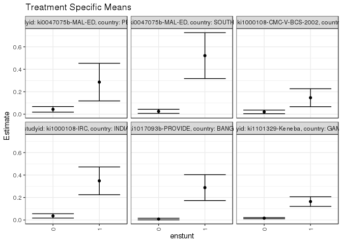

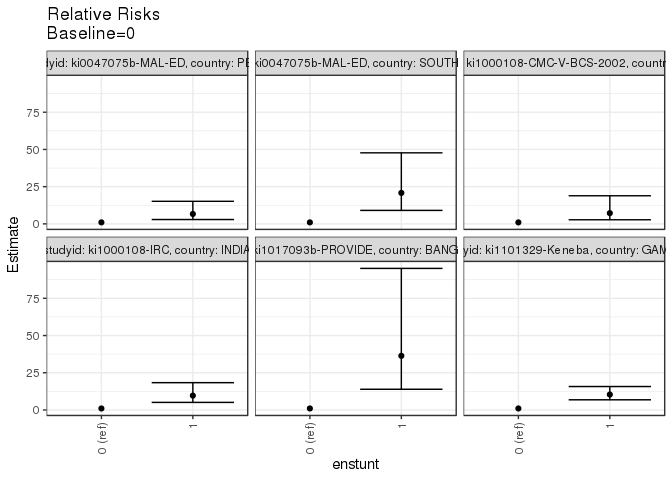

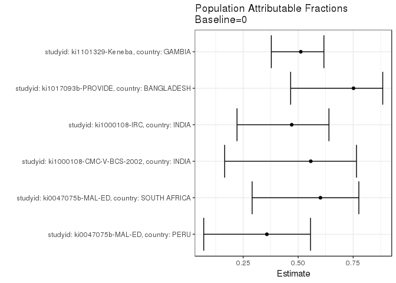

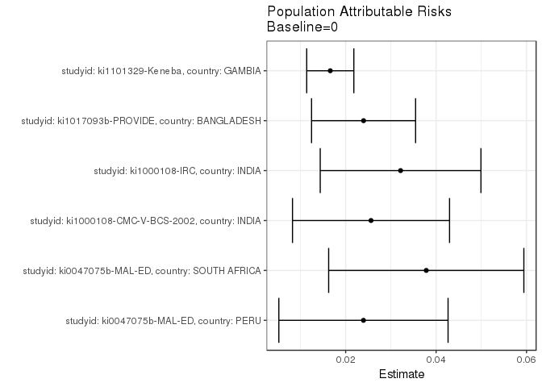

## Results Table

### Parameter: TSM

| studyid | country | intervention_level | baseline_level | estimate | ci_lower | ci_upper |
| --- | --- | --- | --- | --- | --- | --- |
| ki0047075b-MAL-ED | PERU | 0 | NA | 0.0429688 | 0.0180840 | 0.0678535 |
| ki0047075b-MAL-ED | PERU | 1 | NA | 0.2857143 | 0.1180900 | 0.4533386 |
| ki0047075b-MAL-ED | SOUTH AFRICA | 0 | NA | 0.0250896 | 0.0067075 | 0.0434717 |
| ki0047075b-MAL-ED | SOUTH AFRICA | 1 | NA | 0.5217391 | 0.3172532 | 0.7262251 |
| ki1000108-CMC-V-BCS-2002 | INDIA | 0 | NA | 0.0203390 | 0.0042092 | 0.0364687 |
| ki1000108-CMC-V-BCS-2002 | INDIA | 1 | NA | 0.1466667 | 0.0664933 | 0.2268400 |
| ki1000108-IRC | INDIA | 0 | NA | 0.0361456 | 0.0168416 | 0.0554496 |
| ki1000108-IRC | INDIA | 1 | NA | 0.3485760 | 0.2247628 | 0.4723892 |
| ki1017093b-PROVIDE | BANGLADESH | 0 | NA | 0.0079239 | 0.0010010 | 0.0148469 |
| ki1017093b-PROVIDE | BANGLADESH | 1 | NA | 0.2881356 | 0.1724887 | 0.4037825 |
| ki1101329-Keneba | GAMBIA | 0 | NA | 0.0158202 | 0.0106552 | 0.0209851 |
| ki1101329-Keneba | GAMBIA | 1 | NA | 0.1638609 | 0.1208285 | 0.2068933 |

### Parameter: E(Y)

| studyid | country | intervention_level | baseline_level | estimate | ci_lower | ci_upper |
| --- | --- | --- | --- | --- | --- | --- |
| ki0047075b-MAL-ED | PERU | NA | NA | 0.0669014 | 0.0377918 | 0.0960110 |
| ki0047075b-MAL-ED | SOUTH AFRICA | NA | NA | 0.0629139 | 0.0354838 | 0.0903440 |
| ki1000108-CMC-V-BCS-2002 | INDIA | NA | NA | 0.0459459 | 0.0245838 | 0.0673081 |
| ki1000108-IRC | INDIA | NA | NA | 0.0682927 | 0.0438464 | 0.0927390 |
| ki1017093b-PROVIDE | BANGLADESH | NA | NA | 0.0318841 | 0.0187654 | 0.0450027 |
| ki1101329-Keneba | GAMBIA | NA | NA | 0.0324149 | 0.0254265 | 0.0394034 |

### Parameter: RR

| studyid | country | intervention_level | baseline_level | estimate | ci_lower | ci_upper |
| --- | --- | --- | --- | --- | --- | --- |
| ki0047075b-MAL-ED | PERU | 0 | 0 | 1.000000 | 1.000000 | 1.00000 |
| ki0047075b-MAL-ED | PERU | 1 | 0 | 6.649351 | 2.915793 | 15.16358 |
| ki0047075b-MAL-ED | SOUTH AFRICA | 0 | 0 | 1.000000 | 1.000000 | 1.00000 |
| ki0047075b-MAL-ED | SOUTH AFRICA | 1 | 0 | 20.795031 | 9.059479 | 47.73269 |
| ki1000108-CMC-V-BCS-2002 | INDIA | 0 | 0 | 1.000000 | 1.000000 | 1.00000 |
| ki1000108-CMC-V-BCS-2002 | INDIA | 1 | 0 | 7.211111 | 2.752293 | 18.89338 |
| ki1000108-IRC | INDIA | 0 | 0 | 1.000000 | 1.000000 | 1.00000 |
| ki1000108-IRC | INDIA | 1 | 0 | 9.643672 | 5.073066 | 18.33219 |
| ki1017093b-PROVIDE | BANGLADESH | 0 | 0 | 1.000000 | 1.000000 | 1.00000 |
| ki1017093b-PROVIDE | BANGLADESH | 1 | 0 | 36.362712 | 13.902733 | 95.10697 |
| ki1101329-Keneba | GAMBIA | 0 | 0 | 1.000000 | 1.000000 | 1.00000 |
| ki1101329-Keneba | GAMBIA | 1 | 0 | 10.357712 | 6.818155 | 15.73478 |

### Parameter: PAR

| studyid | country | intervention_level | baseline_level | estimate | ci_lower | ci_upper |
| --- | --- | --- | --- | --- | --- | --- |
| ki0047075b-MAL-ED | PERU | 0 | NA | 0.0239327 | 0.0052184 | 0.0426469 |
| ki0047075b-MAL-ED | SOUTH AFRICA | 0 | NA | 0.0378243 | 0.0162378 | 0.0594108 |
| ki1000108-CMC-V-BCS-2002 | INDIA | 0 | NA | 0.0256070 | 0.0082390 | 0.0429749 |
| ki1000108-IRC | INDIA | 0 | NA | 0.0321471 | 0.0143720 | 0.0499222 |
| ki1017093b-PROVIDE | BANGLADESH | 0 | NA | 0.0239601 | 0.0124550 | 0.0354653 |
| ki1101329-Keneba | GAMBIA | 0 | NA | 0.0165947 | 0.0113831 | 0.0218063 |

### Parameter: PAF

| studyid | country | intervention_level | baseline_level | estimate | ci_lower | ci_upper |
| --- | --- | --- | --- | --- | --- | --- |
| ki0047075b-MAL-ED | PERU | 0 | NA | 0.3577303 | 0.0708369 | 0.5560409 |
| ki0047075b-MAL-ED | SOUTH AFRICA | 0 | NA | 0.6012073 | 0.2908457 | 0.7757391 |
| ki1000108-CMC-V-BCS-2002 | INDIA | 0 | NA | 0.5573280 | 0.1660357 | 0.7650277 |
| ki1000108-IRC | INDIA | 0 | NA | 0.4707256 | 0.2221012 | 0.6398871 |
| ki1017093b-PROVIDE | BANGLADESH | 0 | NA | 0.7514767 | 0.4657798 | 0.8843851 |
| ki1101329-Keneba | GAMBIA | 0 | NA | 0.5119473 | 0.3780494 | 0.6170187 |